# clean bayescan ALL SAMPLES NO LOWDATA processing

Ash Iwikau

2025-07-16

### Load ggplots

```r
library(ggplot2)
library(tidyverse)
```

### Read in data

```r
bayescan = read.table("no_island_bayescan_input.g_fst.txt", header=TRUE)
```

### Load in txt file with CHROM, POS, SNPID from VCF file

```r
snppositions = read.table("renamed_bysize_bayescan_positions.txt", header=FALSE)
```

### Bind to bayescan results

```r
bayescan=cbind(snppositions, bayescan)
```

### Rename columns

```r
colnames(bayescan)=c("CHROM","POSIT","SNPID","PROB","LOG_PO","Q_VALUE","ALPHA","FST")
```

### Extract numeric part of CHROM

```r
bayescan$CHROM_numeric = as.numeric(gsub("scaffold_(\\d+)", "\\1", bayescan$CHROM))
```

### Sort by numeric chrom # and remove this temp column

```r
bayescan_sorted = bayescan[order(bayescan$CHROM_numeric),]

bayescan_sorted$CHROM_numeric <- NULL
```

### Assign selection as diversifying/neutral/balancing?

```r
bayescan_sorted$SELECTION <- ifelse(bayescan_sorted$ALPHA>=0&bayescan_sorted$Q_VALUE<=0.01,"diversifying",
                ifelse(bayescan_sorted$ALPHA>=0&bayescan_sorted$Q_VALUE>0.01,"neutral","balancing"))

bayescan_sorted$SELECTION<- factor(bayescan_sorted$SELECTION)
```

Marking everything with a qval less than 0.01 as diversifying and the others as neutral/balancing

This is probably not super necessary but I think I use it as a quick way of colouring the elbow plot later so may as well keep

```r
bayescan_sorted[bayescan_sorted$Q_VALUE<=0.00001,"Q_VALUE"]=0.00001
```

### Check how many have a significant q val

```r
sum(bayescan_sorted$Q_VALUE <=0.01)
```

```
## [1] 37
```

```r
sum(bayescan_sorted$Q_VALUE <=0.05)
```

```
## [1] 43
```

### Log the q values

```r
bayescan_sorted$LOG10_Q <- -log10(bayescan_sorted$Q_VALUE)
```

```r
bayescan_sorted$SIG = ifelse(bayescan_sorted$Q_VALUE < 0.01, "Signficant", "Non-significant")
```

```r
bayescan_sorted %>% group_by(SIG) %>% tally()
```

```
## # A tibble: 2 × 2
##   SIG                 n
##   <chr>           <int>
## 1 Non-significant 43985
## 2 Signficant         37
```

### Write out the full table to a tsv file

```r
#write.table(bayescan_sorted, file = "no_islands_no_lowdata_bayescan_results.txt", sep = "\t",
#            row.names = FALSE, col.names = TRUE)
```

### Make new obj that only has the sig ones (just coz)

```r
sigbayescan = bayescan_sorted[bayescan_sorted$Q_VALUE<=0.01 ,]
```

### Write significant q value results to its own tsv

```r
#write.table(sigbayescan, file = "no_islands_no_lowdata_significant_bayescan_results.txt", sep = "\t",
#            row.names = FALSE, col.names = TRUE)
```

### Order by q value?

```r
qsortedbayescan = bayescan_sorted[order(bayescan_sorted$Q_VALUE, decreasing = FALSE),]
```

## Plotting

Set axis names

```r
x_title="-Log10(q-value)"
y_title="Fst"
```

Make some log significance cutoffs to put some lines

```r
log_cutoff = -log10(0.05)
log_cutoff_0.01 = -log10(0.01)
```

Make the graph obj

```r
graph_1 = ggplot(bayescan_sorted,aes(x=LOG10_Q,y=FST))
```

Add some stuff on the graph

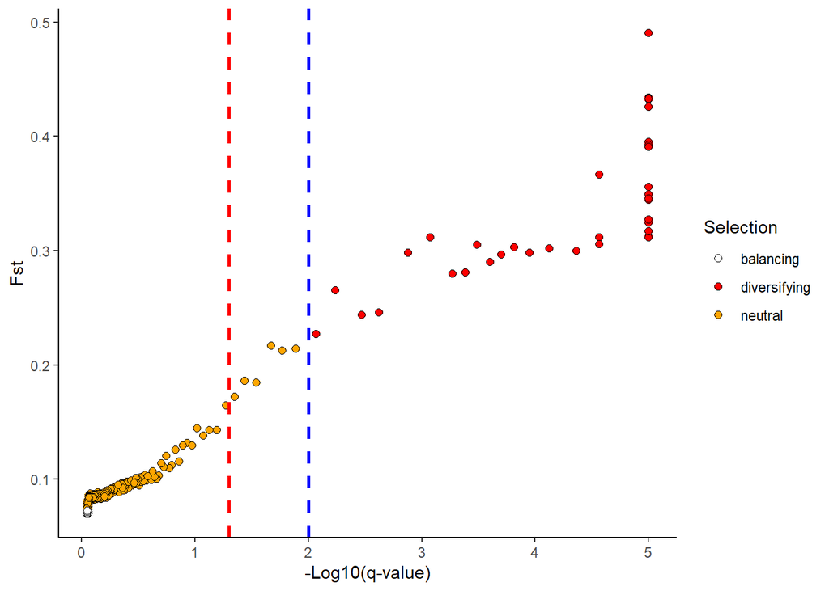

```r
graph_1+geom_point(aes(fill= SELECTION), pch=21, size=2)+
  #geom_text()+
  scale_fill_manual(name="Selection",values=c("white","red","orange"))+
  labs(x=x_title)+
  labs(y=y_title)+
  theme(axis.title=element_text(size=12, family="Helvetica",face="bold"), legend.position="none")+
  theme(axis.text.x=element_text(colour="black"))+
  theme(axis.text.y=element_text(colour="black",size=12))+
  theme(axis.text.x=element_text(colour="black",size=12))+
  theme(panel.border = element_rect(colour="black", fill=NA, size=3),
        axis.title=element_text(size=18,colour="black",family="Helvetica",face="bold")) +
  theme_classic() +
  geom_vline(xintercept = log_cutoff, linetype="dashed", color="red", size=1) +
  geom_vline(xintercept = log_cutoff_0.01, linetype="dashed", color="blue", size=1)
```

Heres one where I changed the colours/legend i guess

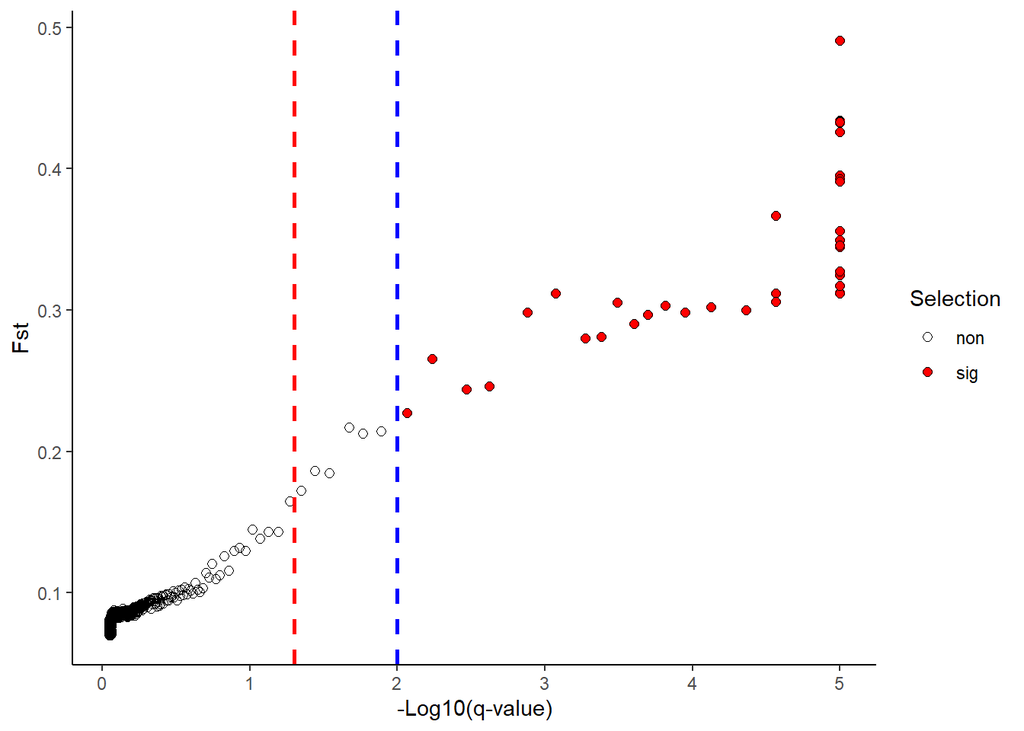

```r
graph_1 +
  geom_point(aes(fill = ifelse(SELECTION == "diversifying", "sig", "non")), pch=21, size=2) +
  #geom_text()+
  scale_fill_manual(name = "Selection", values = c("sig" = "red", "non" = "transparent")) +
  labs(x=x_title)+
  labs(y=y_title)+
  theme(axis.title=element_text(size=12, family="Helvetica",face="bold"), legend.position="none")+
  theme(axis.text.x=element_text(colour="black"))+
  theme(axis.text.y=element_text(colour="black",size=12))+
  theme(axis.text.x=element_text(colour="black",size=12))+
  theme(panel.border = element_rect(colour="black", fill=NA, size=3),
        axis.title=element_text(size=18,colour="black",family="Helvetica",face="bold")) +
  theme_classic() +
  geom_vline(xintercept = log_cutoff, linetype="dashed", color="red", size=1) +
  geom_vline(xintercept = log_cutoff_0.01, linetype="dashed", color="blue", size=1)
```

```r
  #geom_vline(xintercept = log_cutoff_gwas, linetype="dashed", color="blue", size=1)
```

# FST ANALYSIS AND MANHATTAN PLOTTING

```r
quantile(bayescan_sorted$FST, c(0.975, 0.995, 0.999), na.rm = T)
```

```
##      97.5%      99.5%      99.9%
## 0.08475100 0.08632058 0.14503947
```

```r
range(bayescan_sorted$FST)
```

```
## [1] 0.069746 0.490690
```

highest fst is 0.491

```r
quant_threshold = quantile( bayescan_sorted$FST, 0.995 )
```

```r
SECONDquant_threshold = quantile( bayescan_sorted$FST, 0.999 )
```

```r
bayescan_sorted = bayescan_sorted %>% mutate(OUTLIER = ifelse(bayescan_sorted$FST > SECONDquant_threshold, "outlier", "background"))
```

### How many outliers are there

```r
bayescan_sorted %>% group_by(OUTLIER) %>% tally()
```

```
## # A tibble: 2 × 2
##   OUTLIER        n
##   <chr>      <int>
## 1 background 43977
## 2 outlier       45
```

this is more than found sig in the bayescan processing above ^ coz that was based off of significance cutoffs

```r
sigbayescan %>% group_by(CHROM) %>% tally()
```

```
## # A tibble: 6 × 2
##   CHROM             n
##   <chr>         <int>
## 1 scaffold_0003     1
## 2 scaffold_0007     1
## 3 scaffold_0021    24
## 4 scaffold_0037     4
## 5 scaffold_0080     5
## 6 scaffold_0112     2
```

**further filter outliers based on qval maybe? lets just see if the plotting still works first**

## MANHATTANS

### Make obj a df coz its easier to work w

```r
df_bayescan = as.data.frame(bayescan_sorted)
```

### Just straight plot no nuance

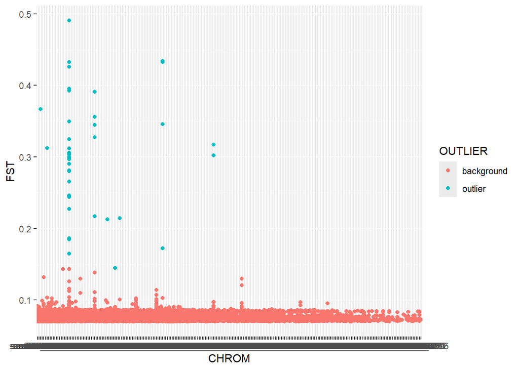

```r
ggplot(df_bayescan, aes(CHROM, FST, colour = OUTLIER)) +
  geom_point()
```

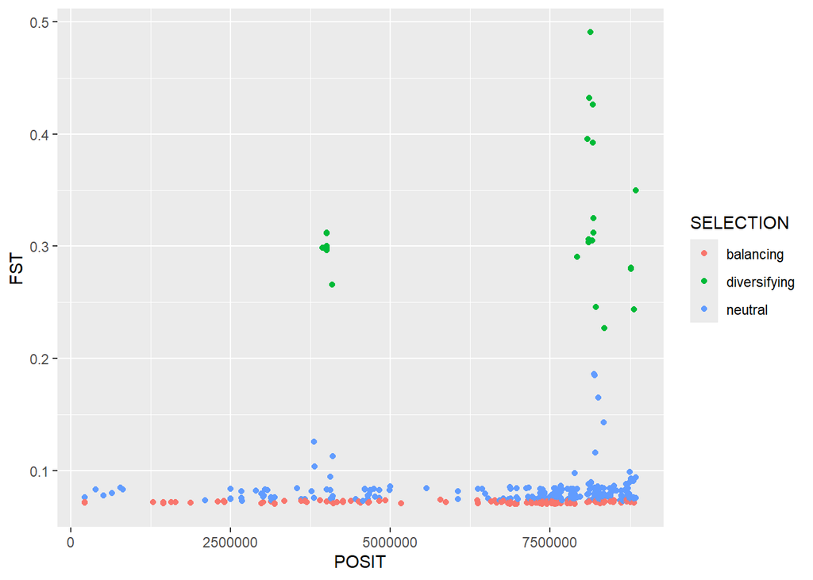

```r
ggplot(df_bayescan %>% filter(CHROM == "scaffold_0021"),
       aes(POSIT, FST, colour = SELECTION))+geom_point()
```

### Calc cumulative positions (so can graph in order)

```r
cumulative_position = df_bayescan  %>%
  group_by(CHROM) %>%
  summarise(max_bp = max(POSIT)) %>%
  mutate(bp_add = lag(cumsum(max_bp), default = 0)) %>%
  select(CHROM, bp_add)
```

### Add back to original data

```r
df_bayescan <- df_bayescan %>%
  inner_join(cumulative_position, by = "CHROM") %>%
  mutate(CUMULATIVEBP = POSIT + bp_add)
```

### Set the middle of each scaffold for labelling (still looks like shit but w/e)

```r
axis_set = df_bayescan |>
  group_by(CHROM) |>
  summarize(center = mean(CUMULATIVEBP))
```

### Now plot full manhattan

```r
manhattan_fst = ggplot(df_bayescan,
                       aes(x = CUMULATIVEBP, y = FST, color = as_factor(CHROM))) +
  geom_point(size = 3 , alpha = 0.5, ) +
  scale_x_continuous( label = axis_set$CHROM, breaks = axis_set$center) +
  scale_color_manual(values = rep(c("darkgrey", "#363636"), unique(length(axis_set$CHROM)) )) +
  geom_point(data=subset(df_bayescan, SIG=="Signficant"), color="red", size=3, alpha = 0.5) +
  labs( x = NULL, y = (expression(F[ST])) , ) +
  theme_minimal() +
  theme(
    legend.position = "none",
    panel.grid.major.x = element_blank(),
    panel.grid.minor.x = element_blank(),
    panel.grid.major.y = element_blank(),
    panel.grid.minor.y = element_blank(),
    axis.text.x = element_text(angle = 60, size = 4, vjust = 0.5))
```

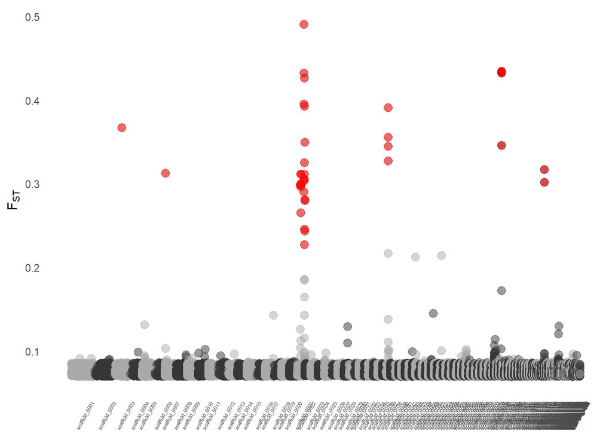

```r
manhattan_fst
```

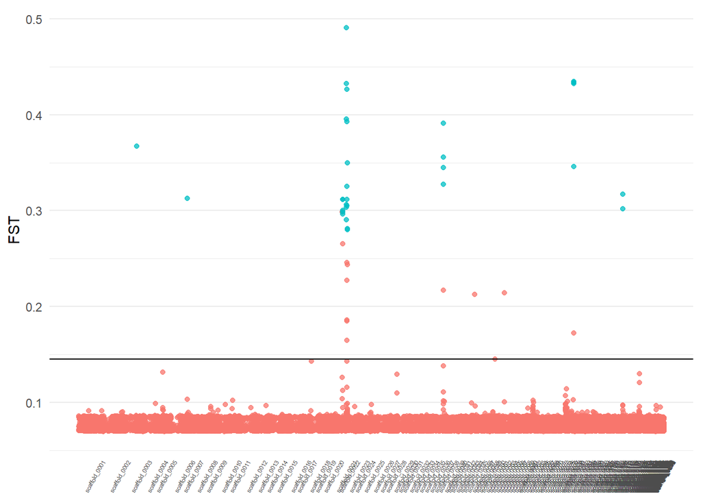

```r
ggplot(df_bayescan, aes(
  x = CUMULATIVEBP, y = (FST),
  color = (Q_VALUE <= 0.001))) +
  geom_point(size = 1.5, alpha = 0.75) +
  geom_hline( yintercept = SECONDquant_threshold) +
  scale_x_continuous(
    label = axis_set$CHROM,
    breaks = axis_set$center) +
  labs(
    x = NULL ,
    y = "FST" ,
  ) +
  theme_minimal() +
  theme(
    legend.position = "none",
    panel.grid.major.x = element_blank(),
    panel.grid.minor.x = element_blank(),
    axis.text.x = element_text(angle = 60, size = 4, vjust = 0.5)
  )
```

[figure not shown]

```r
ggplot(df_bayescan %>% filter(CHROM == "ptg000017l_1"), aes(
  x = CUMULATIVEBP, y = (FST),
  color = (Q_VALUE <= 0.01))) +
  geom_point(size = 2, alpha = 0.75) +
  #geom_hline( yintercept = quant_threshold) +
  #geom_hline( yintercept = SECONDquant_threshold) +
  labs(
    x = "Scaffold ptg000017" ,
    y = "FST"
  ) +
  theme_minimal() +
  theme(
    legend.position = "none",
    panel.grid.major.x = element_blank(),
    panel.grid.minor.x = element_blank(),
    axis.text.x=element_blank()
  )
```

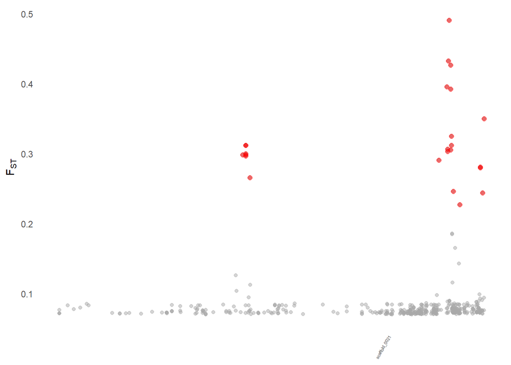

```r
ggplot(df_bayescan %>% filter(CHROM == "scaffold_0021"),
                       aes(x = CUMULATIVEBP, y = FST, color = as_factor(CHROM))) +
  geom_point(size = 1.5, alpha = 0.5, ) +
  scale_x_continuous( label = axis_set$CHROM, breaks = axis_set$center) +
  scale_color_manual(values = rep(c("darkgrey", "#363636"), unique(length(axis_set$CHROM)) )) +
  geom_point(data=subset(df_bayescan %>% filter(CHROM == "scaffold_0021"), SIG=="Signficant"), color="red", size=2, alpha = 0.5,) +
  labs( x = NULL, y = (expression(F[ST])) , ) +
  theme_minimal() +
  theme(
    legend.position = "none",
    panel.grid.major.x = element_blank(),
    panel.grid.minor.x = element_blank(),
      panel.grid.major.y = element_blank(),
    panel.grid.minor.y = element_blank(),
    axis.text.x = element_text(angle = 60, size = 4, vjust = 0.5))
```

[figure not shown]

```r
ggplot(df_bayescan %>% filter(CHROM == "ptg000077l_1"), aes(
  x = CUMULATIVEBP, y = (FST),
  color = (Q_VALUE <= 0.01))) +
  geom_point(size = 2, alpha = 0.75) +
  #geom_hline( yintercept = quant_threshold) +
  #geom_hline( yintercept = SECONDquant_threshold) +
  labs(
    x = "Scaffold ptg000077" ,
    y = "FST"
  ) +
  theme_minimal() +
  theme(
    legend.position = "none",
    panel.grid.major.x = element_blank(),
    panel.grid.minor.x = element_blank(),
    axis.text.x=element_blank()
  )
```